# Initial Data Inspection

Yunfei Yu, 1005976918

2026-02-28

```r
library(readxl)
library(dplyr)
library(tidyverse)
library(kableExtra)
library(knitr)
library(skimr)
library(naniar)
# library(VIM)
library(gtsummary)
library(gt)
library(forcats)
```

```r
source("helper_functions.R")
```

# 1 Outline

## Scales

7-point Likert Scale. 8 = Not Applicable.

1. Check distributions of scores for each item (including 8 and missing).
2. Check missing values (percentage missing in each survey item, and missing patterns across all items and all scales). 2.1 Explore demographic differences between the missing vs. non-missing groups. 2.2 Explore demographic difference between the “actual missing (NA)” group vs. people who chose 8.
3. Compute mean scores and standard deviations for each item after removing NAs and 8.

## Demographics

1. Attach labels to the demographic (checkbox) dummy variables (i.e. “collapsing” multiple dummies into a categorical variable)
2. Check distributions
3. Check missing values and missing patterns
4. Compute summary statistics

```r
raw.data <- read_excel("Data/FINAL_ProjectOATH_DATA_2024-05-08_1639.xlsx")
# raw.data %>% skim()
```

```r
# check for any duplicates in record id
nrow(raw.data) == n_distinct(raw.data$record_id)
```

```
## [1] TRUE
```

# 2 Scales

## 2.1 Organizational Ambidexterity Survey - Exploration

### 2.1.1 Check distributions

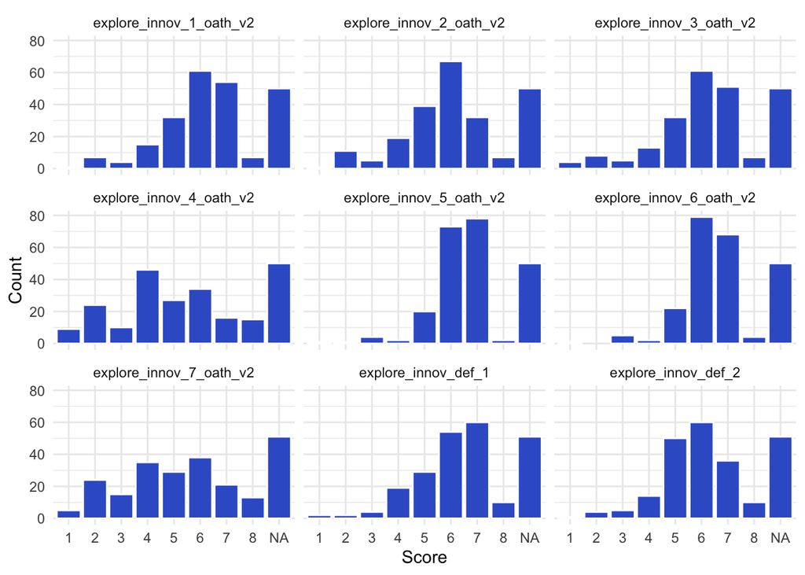

Distribution of exploration survey scores

```r
# plot distributions for each item in exploration survey
plt_scale_dist(raw.data, prefix = "explore")
```

### 2.1.2 Check missing and completion rates

```r
# check missingness in exploration scale items
# get_missing_stats is a helper function from helper_functions.R
get_missing_stats(data = raw.data, prefix = "explore", caption = "Exploration scale completion rate")
```

Exploration scale completion rate

| scale item | n missing | missing rate | completion rate |
| --- | --- | --- | --- |
| explore_innov_1_oath_v2 | 50 | 21.65 | 78.35 |
| explore_innov_2_oath_v2 | 50 | 21.65 | 78.35 |
| explore_innov_3_oath_v2 | 50 | 21.65 | 78.35 |
| explore_innov_4_oath_v2 | 50 | 21.65 | 78.35 |
| explore_innov_5_oath_v2 | 50 | 21.65 | 78.35 |
| explore_innov_6_oath_v2 | 50 | 21.65 | 78.35 |
| explore_innov_7_oath_v2 | 51 | 22.08 | 77.92 |
| explore_innov_def_1 | 51 | 22.08 | 77.92 |
| explore_innov_def_2 | 51 | 22.08 | 77.92 |

## 2.2 Organizational Ambidexterity Survey - Exploitation

### 2.2.1 Check distributions

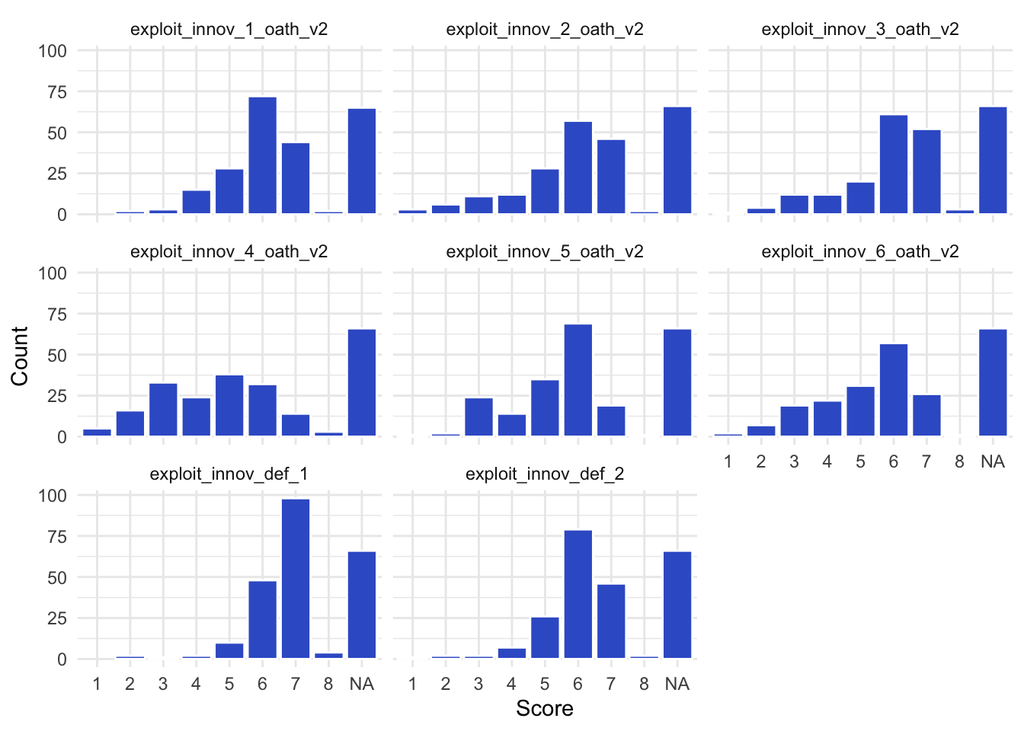

Distribution of exploitation survey scores

```r
# plot distributions for each item in exploitation survey
plt_scale_dist(raw.data, prefix = "exploit")
```

### 2.2.2 Check missing and completion rates

```r
# check missingness in exploitation scale items
get_missing_stats(data = raw.data, prefix = "exploit", caption = "Exploitation scale completion rate")
```

Exploitation scale completion rate

| scale item | n missing | missing rate | completion rate |
| --- | --- | --- | --- |
| exploit_innov_1_oath_v2 | 65 | 28.14 | 71.86 |
| exploit_innov_2_oath_v2 | 66 | 28.57 | 71.43 |
| exploit_innov_3_oath_v2 | 66 | 28.57 | 71.43 |
| exploit_innov_4_oath_v2 | 66 | 28.57 | 71.43 |
| exploit_innov_5_oath_v2 | 66 | 28.57 | 71.43 |
| exploit_innov_6_oath_v2 | 66 | 28.57 | 71.43 |
| exploit_innov_def_1 | 66 | 28.57 | 71.43 |
| exploit_innov_def_2 | 66 | 28.57 | 71.43 |

## 2.3 De-implementation Survey

### 2.3.1 Check distributions

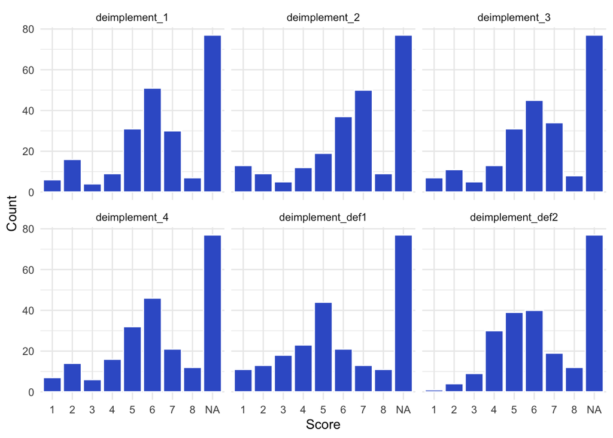

Distribution of deimplementation survey scores

```r
# plot distributions for each item in deimp survey
plt_scale_dist(raw.data, prefix = "deimplement")
```

### 2.3.2 Check missing and completion rates

```r
# check missingness in exploitation scale items
get_missing_stats(data = raw.data, prefix = "deimplement", caption = "De-implementation scale completion rate")
```

De-implementation scale completion rate

| scale item | n missing | missing rate | completion rate |
| --- | --- | --- | --- |
| deimplement_1 | 77 | 33.33 | 66.67 |
| deimplement_2 | 77 | 33.33 | 66.67 |
| deimplement_3 | 77 | 33.33 | 66.67 |
| deimplement_4 | 77 | 33.33 | 66.67 |
| deimplement_def1 | 77 | 33.33 | 66.67 |
| deimplement_def2 | 77 | 33.33 | 66.67 |

# 3 Demographics

## 3.1 Site and Role

- Primary site `site_oath_v2`: categorical (factor)
- Role `role_oath_v2`: categorical (factor)
  - `role_oath_spec` if `role_oath_v2` = 7: text
- Number of years in current role `years_role_oath_v2`: categorical (factor)
- Number of years at THP `years_employed_thp_v2`: categorical (factor)
- Have academic appoint `academic_appt`: binary

```r
labelled.data <- raw.data %>%
  # convert to factor and attach text labels for summary
  mutate(
    site_oath_v2 = factor(site_oath_v2,
                          levels = c(1, 2, 3, 4),
                          labels = c("Credit Valley Hospital",
                                     "Missisauga Hospital",
                                     "Queensway Health Centre",
                                     "Other")
                          ),
    role_oath_v2 = factor(role_oath_v2,
                          levels = c(1, 2, 3, 4, 5, 6, 7),
                          labels = c("Administrative/Consultant",
                                     "Director",
                                     "Manager",
                                     "Professional Staff",
                                     "Senior Leadership",
                                     "Supervisor/Team Leader",
                                     "Other")
                          ),
    years_role_oath_v2 = factor(years_role_oath_v2,
                                levels = c(1, 2, 3, 4, 5),
                                labels = c("<1 year",
                                           "1-3 years",
                                           "3-6 years",
                                           "6-9 years",
                                           "10+ years")
                                ),
    years_employed_thp_v2 = factor(years_employed_thp_v2,
                                   levels = c(1, 2, 3, 4, 5),
                                   labels = c("<1 year",
                                              "1-3 years",
                                              "3-6 years",
                                              "6-9 years",
                                              "10+ years")
                                   ),
    academic_appt = factor(academic_appt,
                           levels = c(1, 0),
                           labels = c("Yes", "No"))
  )
```

```r
# Missings are treated as an explicit category only for reporting
get_category_summary(labelled.data,
                     caption = "Summary statistics (n (%)) for site and role variables",
                     id = "record_id")
```

Summary statistics (n (%)) for site and role variables

| **Characteristic** | **N = 231**<sup>1</sup> |
| --- | --- |
| redcap_event_name |  |
| general_survey_dis_arm_1 | 231 (100%) |
| redcap_survey_identifier | 0 (NA%) |
| site_oath_v2 |  |
| Credit Valley Hospital | 79 (34%) |
| Missisauga Hospital | 72 (31%) |
| Queensway Health Centre | 11 (4.8%) |
| Other | 50 (22%) |
| Missing | 19 (8.2%) |
| role_oath_v2 |  |
| Administrative/Consultant | 12 (5.2%) |
| Director | 42 (18%) |
| Manager | 74 (32%) |
| Professional Staff | 27 (12%) |
| Senior Leadership | 12 (5.2%) |
| Supervisor/Team Leader | 34 (15%) |
| Other | 11 (4.8%) |
| Missing | 19 (8.2%) |
| role_oath_spec |  |
| clinical educator | 1 (11%) |
| Clinical Educator | 5 (56%) |
| educator | 1 (11%) |
| Educator | 1 (11%) |
| Practice Leader | 1 (11%) |
| years_role_oath_v2 |  |
| <1 year | 47 (20%) |
| 1-3 years | 74 (32%) |
| 3-6 years | 40 (17%) |
| 6-9 years | 24 (10%) |
| 10+ years | 28 (12%) |

[output cut: 624 more lines]

## 3.2 Demographics

- Age `age_oath_v2`: categorical
- Gender `gender_oath_v2`: checkbox
  - Self-definition of gender `self_define_gender` only if `gender_oath_v2` = 5: text
- Sexual orientation `sexual_orient_oath_v2`: checkbox
  - Self definition of sexual orientation `self_define_sex1` only if `sexual_orient_oath_v2` = 7: text
- Disability `disability_oath_v2`: categorical
- Indigenous `indigenous_oath_v2`: categorical
- Visible minority / people of colour `poc_oath_v2`: categorical
- Language(s) `language_oath_v2`: checkbox (select all apply)
  - Specify `language_specify_oath_v2` only if `language_oath_v2` = 3 or 16: text
- Race `race_oath_v2`: checkbox (select all apply)
  - Specify `race_spec` only if `race_oath_v2` = 7: text

```r
# attach labels to categorical columns
# i.e. age, disability, indigenous, vis min
labelled.data <- labelled.data %>%
  mutate(
    age_oath_v2 = factor(age_oath_v2,
                         levels = c(1, 2, 3, 4, 5, 6),
                         labels = c("<18 years",
                                    "18-29 years",
                                    "30-54 years",
                                    "55-64 years",
                                    "65+ years",
                                    "Prefer not to answer")
                         ),
    disability_oath_v2 = factor(disability_oath_v2,
                                levels = c(1, 2, 3),
                                labels = c("Yes", "No", "Prefer not to answer")
                                ),
    indigenous_oath_v2 = factor(indigenous_oath_v2,
                                levels = c(1, 2, 3),
                                labels = c("Yes", "No", "Prefer not to answer")
                                ),
    poc_oath_v2 = factor(poc_oath_v2,
                         levels = c(1, 2, 3),
                         labels = c("Yes", "No", "Prefer not to answer")
                         )
  )
```

```r
# convert checkbox variables (dummies) to categorical
# i.e. gender, sexual orientation, language, race

# check if gender and sexual orientation is MC or choose all apply
gender_sex <- raw.data %>%
  select(record_id, contains("gender"), contains("sex")) %>%
  mutate(gender_sum = rowSums(pick(starts_with("gender_"))),
         sex_sum = rowSums(pick(starts_with("sexual_"))))

# summary table
get_category_summary(gender_sex %>%
                       select(gender_sum, sex_sum) %>%
                       mutate(gender_sum = as.factor(gender_sum),
                              sex_sum = as.factor(sex_sum)),
                     caption = "")
```

| **Characteristic** | **N = 231**<sup>1</sup> |
| --- | --- |
| gender_sum |  |
| 0 | 22 (9.5%) |
| 1 | 209 (90%) |
| Missing | 0 (0%) |
| sex_sum |  |
| 0 | 22 (9.5%) |
| 1 | 208 (90%) |
| 2 | 1 (0.4%) |
| Missing | 0 (0%) |

<sup>1</sup> n (%)

```r
# if gender = 5, and if self-define is empty ~ other; if self-define not empty ~ self-defined text
```

Gender and sexual orientation are multiple choice in nature (rather than “select all that apply”), except for one person who chose more than one sexual orientation. Some participants did not select any categories for gender and sexual orientations.

```r
# check the one person who choose more than 1 sexual orientation
gender_sex %>%
  filter(sex_sum > 1)
```

```
## # A tibble: 1 × 19
##   record_id gender_oath_v2___1 gender_oath_v2___2 gender_oath_v2___3
##       <dbl>              <dbl>              <dbl>              <dbl>
## 1       228                  1                  0                  0
## # ℹ 15 more variables: gender_oath_v2___4 <dbl>, gender_oath_v2___5 <dbl>,
## #   gender_oath_v2___6 <dbl>, self_define_gender <lgl>,
## #   sexual_orient_oath_v2___1 <dbl>, sexual_orient_oath_v2___2 <dbl>,
## #   sexual_orient_oath_v2___3 <dbl>, sexual_orient_oath_v2___4 <dbl>,
## #   sexual_orient_oath_v2___5 <dbl>, sexual_orient_oath_v2___6 <dbl>,
## #   sexual_orient_oath_v2___7 <dbl>, sexual_orient_oath_v2___8 <dbl>,
## #   self_define_sex1 <lgl>, gender_sum <dbl>, sex_sum <dbl>
```

```r
# check people who did not choose any category
```

# 4 Missing Values

## 4.1 Missingness Pattern across Exploration, Exploitation and De-Implementation Surveys

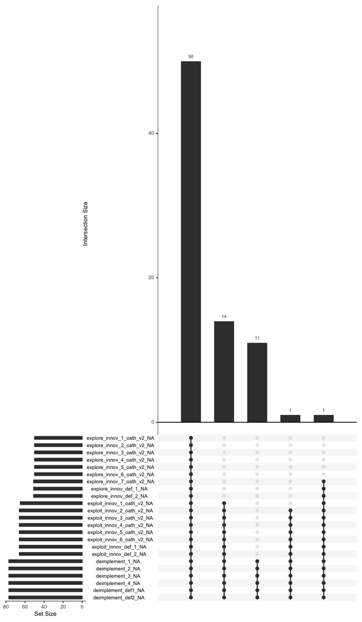

```r
learning.scales <- raw.data %>%
  select(starts_with(c("explore", "exploit", "deimplement")))

gg_miss_upset(learning.scales, nsets = ncol(learning.scales))
```

The Learning Ambidexterity scales and De-implementation scale appear to show highly systematic patterns of missingness. The most common pattern is skipping (missing) all questions in all three scales, followed by those who filled out only the exploration survey but missed the exploitation and de-implementation surveys entirely, and finally those who filled out the exploration and exploitation surveys, but not the de-implementation survey.

This suggests missingness is likely driven by an external factor (ex. specific groups of non-respondents, lost interest, or a specific survey is less relevant), rather than missing at random.

## 4.2 Missingness Pattern for Demographics

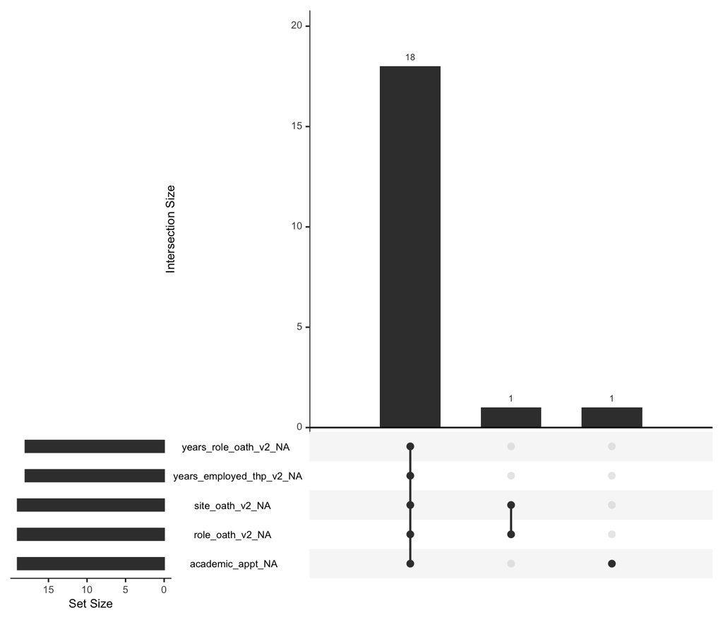

```r
demog_role <- labelled.data %>%
  select(site_oath_v2, role_oath_v2, years_role_oath_v2, years_employed_thp_v2, academic_appt)
gg_miss_upset(demog_role, nsets = ncol(learning.scales))
```